# eda_clue

# Description:

Uses the elife erastin differentially expressed genes based on lfc to explore the clue cell lines treated with erastin. First finds which cell lines show a response to erastin. Then uses these cell lines to find all the genes that change in a uniform way in response to erastin. Then applies these genes to look across all cell lines. Also investigates KRAS mutational status w/in the cell lines as KRAS mutations are consistent with reduced ferroptosis (https://faseb.onlinelibrary.wiley.com/doi/abs/10.1096/fasebj.2020.34.s1.09236)

# Load packages

```r
library('plyr')
library('dplyr')
library('stringr')
library('data.table')
library('tidyverse')
library('magrittr')

library('ComplexHeatmap')
```

# Clean clue data for erastin

Simplifies the erastin clue data (zscores) based on timepoint to allow for downstream analysis.

```r
# clue erastin - loaded as 2 seperate files because of export limits of clue.io
clue.erastin <- fread('/mctp/share/users/rebernrj/projects/ferroptosisGeneSig/data/clue/erastin/clue_v1.3_erastin_1.gct', skip = 2, data.table = F)
temp <- fread('/mctp/share/users/rebernrj/projects/ferroptosisGeneSig/data/clue/erastin/clue_v1.3_erastin_2.gct', skip = 2, data.table = F)

# merge clue erastin files
clue.erastin[,90:97] <- temp[,10:17]


# eliminate 24h time point, keeping only 6 hour
clue.erastin =  clue.erastin[, c(rep(T, 9) ,clue.erastin[6, 10:ncol(clue.erastin)] == '6 h')]

# Shift cell line name to column name and eliminate other metadata
colnames(clue.erastin)[10:ncol(clue.erastin)] <- clue.erastin[1,10:ncol(clue.erastin)]
clue.erastin <- clue.erastin[9:length(clue.erastin$id),]

# convert to numeric
clue.erastin[10:ncol(clue.erastin)] <- apply(clue.erastin[10:ncol(clue.erastin)], 2, as.numeric)

# select cols to keep for correlation
clue.erastin %<>% dplyr::select(-id, -pr_gene_title, -pr_is_lm, -pr_is_bing, -self_correlation, -frac_self_rank, -p_value, -gene_space)
```

# Plot expression of genes found across DESeq analysis to find erastin responsive cell lines

Filters the clue data for the genes shown to be differentially expressed (based on fold change > 2) in the erastin dataset. Roughly 40% are present in the clue data set.

```r
# load degs from elife_erastin_deseq analysis
degs <- fread('/mctp/share/users/rebernrj/projects/ferroptosisGeneSig/int/elife2014_erastin/rna_seq/sig_genes_log2fc.txt', data.table = F)
```

```r
# filter clue data for the degs
clue.e.filt <- clue.erastin %>% dplyr::filter(pr_gene_symbol %in% degs$V1)
clue.e.filt %<>%
  set_rownames(clue.e.filt$pr_gene_symbol) %>%
  select(-pr_gene_symbol)

# only 34/86 genes present - show genes not in clue dataset:
#degs$V1[!degs$V1 %in% clue.erastin$pr_gene_symbol]

# prep degs for plotting:
degs.plot <- degs %>% dplyr::select(V1, log2FoldChange) %>% dplyr::filter(V1 %in% rownames(clue.e.filt))
degs.plot %<>%
  set_rownames(degs.plot$V1) %>%
  select(-V1) %>%
  arrange(-log2FoldChange) %>%
  as.matrix()

# prep clue data for plotting
clue.e.filt <- clue.e.filt[order(match(rownames(clue.e.filt),rownames(degs.plot))),]
clue.e.filt %<>% as.matrix()
```

# Plot heatmap

4 seems to be the optimal number of clusters. Will follow up looking only at upregulated genes.

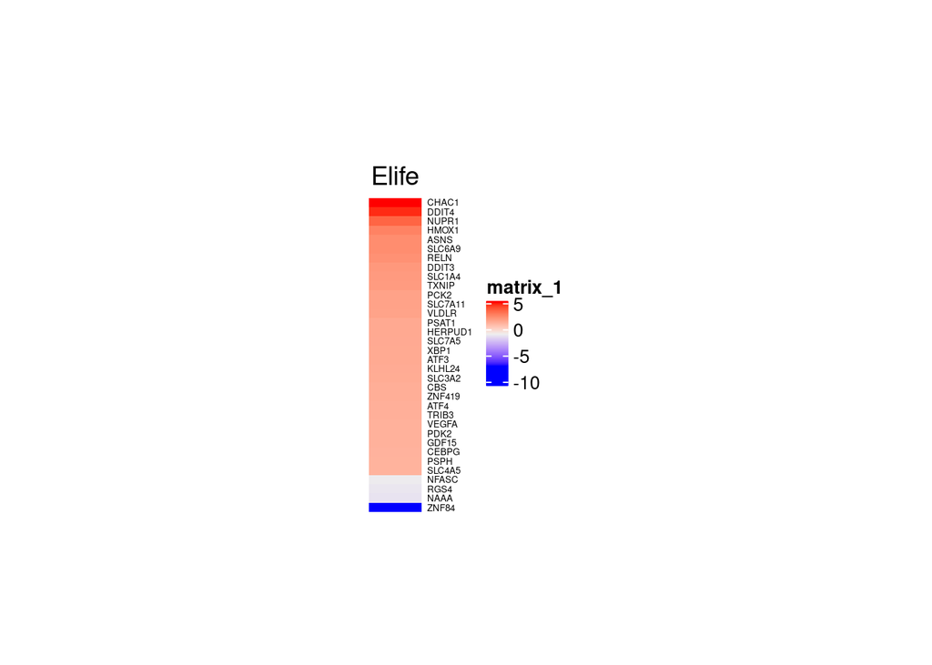

```r
H1 <- Heatmap(degs.plot,
        show_row_dend = F,
        width = unit(1, "cm"),
        height = unit(6, "cm"),
        show_row_names = T,
        row_names_gp = gpar(fontsize = 5),
        show_column_names = F,
        column_title = 'Elife')
H1
```

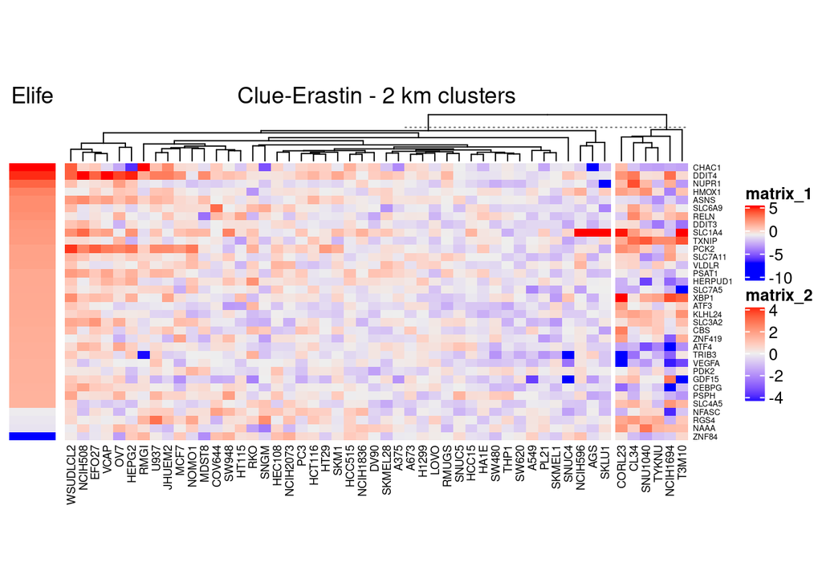

```r
# 2 CLUSTERS
set.seed(11)
H1+ Heatmap(clue.e.filt,
        show_column_dend = T,
        show_row_names = T,
        row_names_gp = gpar(fontsize = 5),
        row_order = c(1:34),
        column_names_gp = gpar(fontsize = 7),
        column_km = 2,
        column_km_repeats = 100,
        column_title = 'Clue-Erastin - 2 km clusters')
```

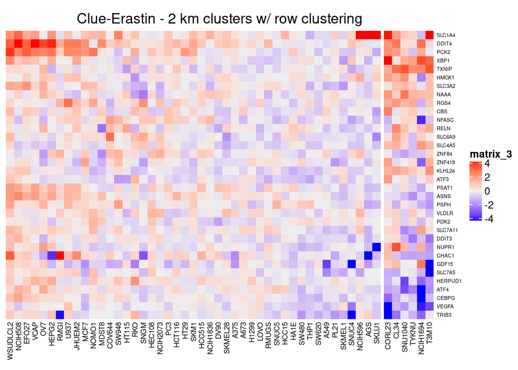

```r
# Looking at the clue data only to allow for clustering
set.seed(11)
Heatmap(clue.e.filt,
        show_column_dend = F,
        show_row_dend = F,
        show_row_names = T,
        row_names_gp = gpar(fontsize = 5),
        column_names_gp = gpar(fontsize = 7),
        column_km = 2,
        column_km_repeats = 100,
        row_km_repeats = 100,
        column_title = 'Clue-Erastin - 2 km clusters w/ row clustering')
```

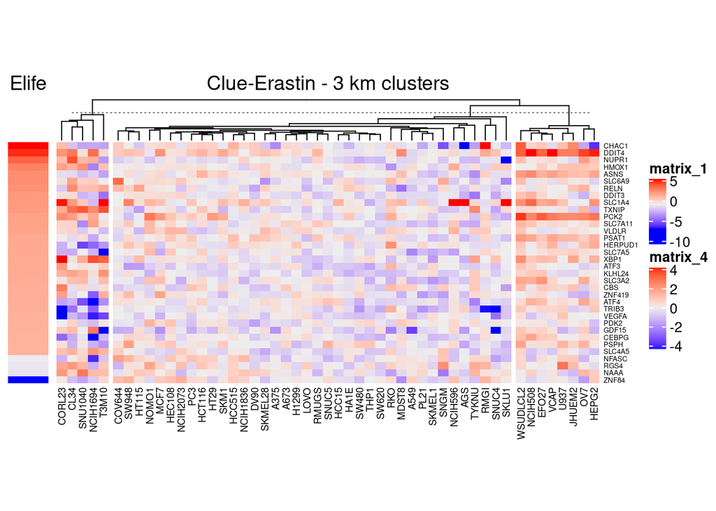

```r
# 3 CLUSTERS
set.seed(11)
H1+ Heatmap(clue.e.filt,
        show_column_dend = T,
        show_row_names = T,
        row_names_gp = gpar(fontsize = 5),
        row_order = c(1:34),
        column_names_gp = gpar(fontsize = 7),
        column_km = 3,
        column_km_repeats = 100,
        column_title = 'Clue-Erastin - 3 km clusters')
```

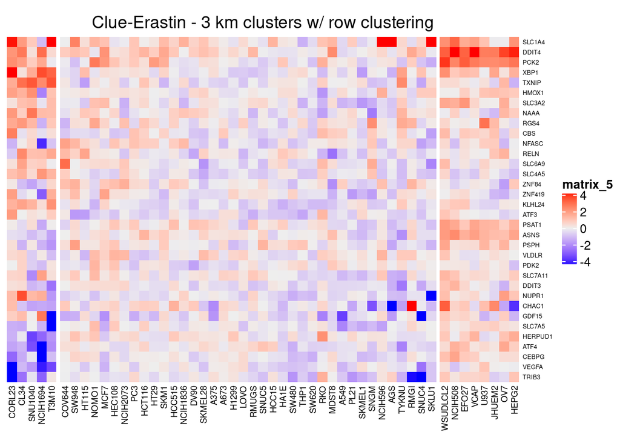

```r
# Looking at the clue data only to allow for clustering
set.seed(11)
Heatmap(clue.e.filt,
        show_column_dend = F,
        show_row_dend = F,
        show_row_names = T,
        row_names_gp = gpar(fontsize = 5),
        column_names_gp = gpar(fontsize = 7),
        column_km = 3,
        column_km_repeats = 100,
        row_km_repeats = 100,
        column_title = 'Clue-Erastin - 3 km clusters w/ row clustering')
```

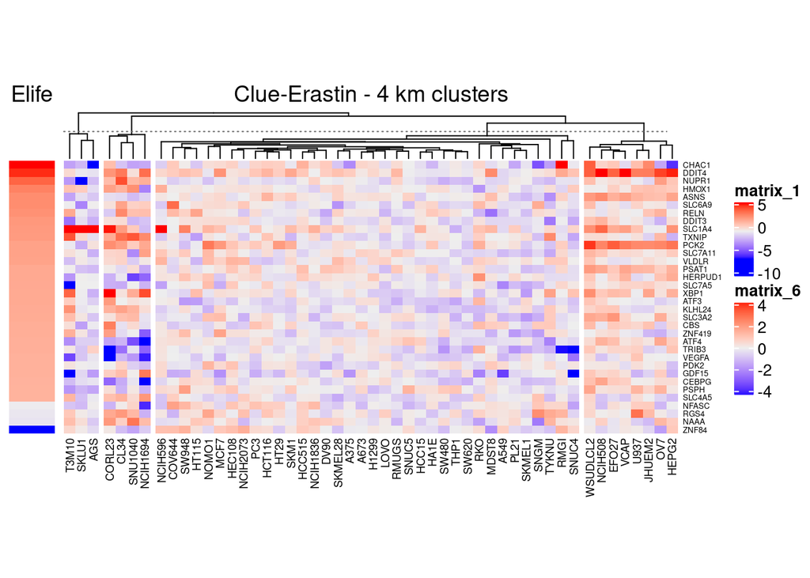

```r
# 4 CLUSTERS
set.seed(11)
H1+ Heatmap(clue.e.filt,
        show_column_dend = T,
        show_row_names = T,
        row_names_gp = gpar(fontsize = 5),
        row_order = c(1:34),
        column_names_gp = gpar(fontsize = 7),
        column_km = 4,
        column_km_repeats = 100,
        column_title = 'Clue-Erastin - 4 km clusters')
```

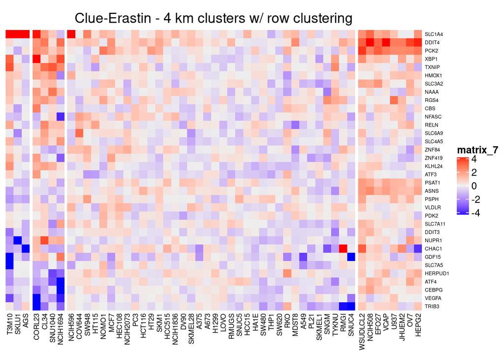

```r
# Looking at the clue data only to allow for clustering
set.seed(11)
Heatmap(clue.e.filt,
        show_column_dend = F,
        show_row_dend = F,
        show_row_names = T,
        row_names_gp = gpar(fontsize = 5),
        column_names_gp = gpar(fontsize = 7),
        column_km = 4,
        column_km_repeats = 100,
        row_km_repeats = 100,
        column_title = 'Clue-Erastin - 4 km clusters w/ row clustering')
```

# Look just at the upregulated genes

This finds the same elements of the cluster on the right as above

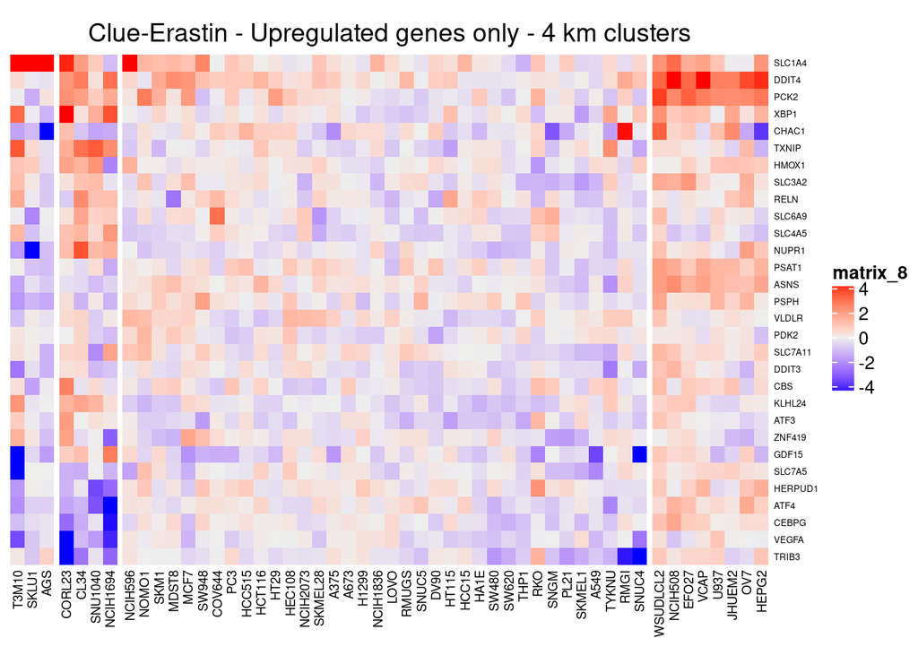

```r
# get upregulated genes only
upreg <- as.data.frame(degs.plot)
upreg %<>% dplyr::filter(log2FoldChange >0)
clue.e.up <- clue.e.filt[rownames(clue.e.filt) %in% rownames(upreg),]


set.seed(11)
Heatmap(clue.e.up,
        show_column_dend = F,
        show_row_dend = F,
        show_row_names = T,
        row_names_gp = gpar(fontsize = 5),
        column_names_gp = gpar(fontsize = 7),
        column_km = 4,
        column_title = 'Clue-Erastin - Upregulated genes only - 4 km clusters')
```

# Extract cell lines from rightmost cluster

This cluster seems to upregulate most of the genes shown to be upregulated by the elife differential expression analysis. Cell lines are printed below.

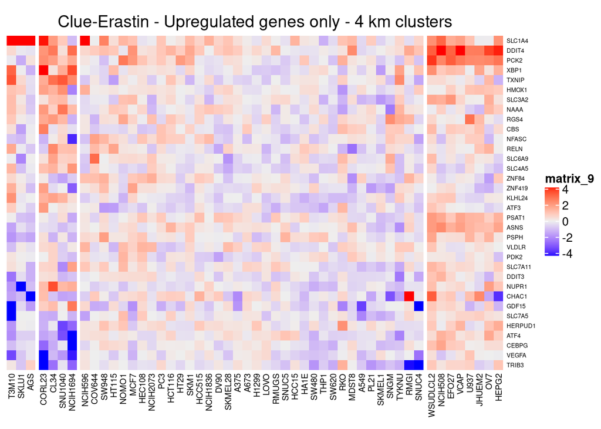

```r
set.seed(11)
H1 <- draw(Heatmap(clue.e.filt,
        show_column_dend = F,
        show_row_dend = F,
        show_row_names = T,
        row_names_gp = gpar(fontsize = 5),
        column_names_gp = gpar(fontsize = 7),
        column_km = 4,
        column_title = 'Clue-Erastin - Upregulated genes only - 4 km clusters'))
```

```r
# cell lines
lines <- colnames(clue.e.filt[,column_order(H1)[[4]]])
lines
```

```
## [1] "WSUDLCL2" "NCIH508"  "EFO27"    "VCAP"     "U937"     "JHUEM2"   "OV7"
## [8] "HEPG2"
```

# View expression of genes in these cell lines

Find the genes with rowSums of z scores >6 who show at least 7/8 cell lines changing in the same direction. However, there is poor concordance between these genes and the ones pulled from the erastin elife data set. Only 8.

```r
# prep cell lines of interest for plotting
## rownames
lines.erastin <- clue.erastin %>%
  set_rownames(clue.erastin$pr_gene_symbol) %>%
  dplyr::select(lines)
```

```
## Note: Using an external vector in selections is ambiguous.
## ℹ Use `all_of(lines)` instead of `lines` to silence this message.
## ℹ See <https://tidyselect.r-lib.org/reference/faq-external-vector.html>.
```

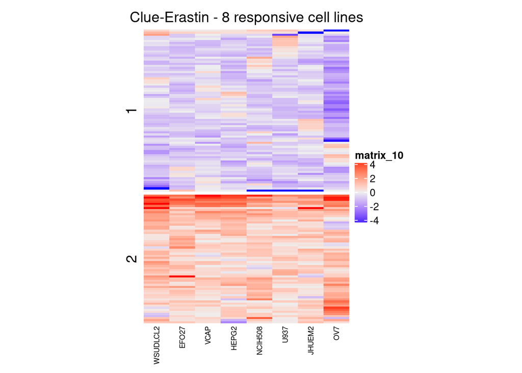

```r
## cumulative z score over 5
lines.erastin %<>% mutate(sums=rowSums(abs(lines.erastin)))
lines.erastin %<>% dplyr::filter(sums >6) %>%
  dplyr::select(-sums)
##7+ cell lines in same direction
lines.erastin %<>%
  dplyr::mutate(sums = (WSUDLCL2 > 0) +
                  (NCIH508 > 0) +
                  (EFO27 > 0) +
                  (VCAP > 0) +
                  (U937 > 0) +
                  (JHUEM2 > 0) +
                  (OV7 > 0) +
                  (HEPG2 > 0))
lines.erastin %<>% dplyr::filter(sums >= 7 | sums <= 1) %>%
  dplyr::select(-sums)


set.seed(11)
Heatmap(lines.erastin,
        show_column_dend = F,
        show_row_dend = F,
        show_row_names = F,
        width = unit(7, "cm"),
        height = unit(10, "cm"),
        column_names_gp = gpar(fontsize = 7),
        row_km = 2,
        column_title = 'Clue-Erastin - 8 responsive cell lines')
```

```r
# The number of differntially expressed present in the initial DEGs set from elife
table(degs$V1 %in% rownames(lines.erastin))
```

```
##
## FALSE  TRUE
##    78     8
```

```r
# What are these genes?
degs$V1[degs$V1 %in% rownames(lines.erastin)]
```

```
## [1] "SLC3A2" "ATF4"   "PSAT1"  "ASNS"   "XBP1"   "PCK2"   "PSPH"   "DDIT4"
```

# Lets see how these genes look across all the cell lines

Plots 140 genes across all cell lines

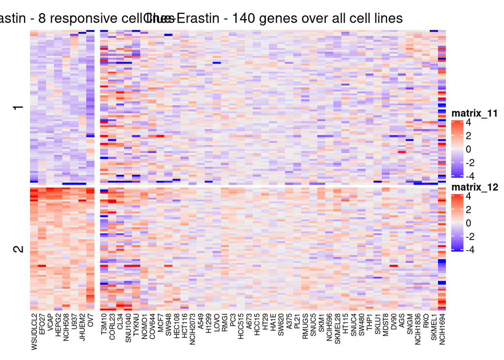

```r
# select 140 genes in all cell ines
clue.erastin.140 <- clue.erastin %>% dplyr::filter(pr_gene_symbol %in% rownames(lines.erastin)) %>% select(-pr_gene_symbol, -lines)

set.seed(11)
Heatmap(lines.erastin,
        show_column_dend = F,
        show_row_dend = F,
        show_row_names = F,
        column_names_gp = gpar(fontsize = 7),
        row_km = 2,
        column_title = 'Clue-Erastin - 8 responsive cell lines') +

Heatmap(clue.erastin.140,
        show_column_dend = F,
        show_row_dend = F,
        show_row_names = F,
        column_names_gp = gpar(fontsize = 7),
        row_km = 2,
        column_title = 'Clue-Erastin - 140 genes over all cell lines')
```

# KRAS status of cell lines

KRAS directly binds GPX4 to inhibit ferroptosis. Stratifying for KRAS WT cell lines would show the best responders.

```r
# Supp table from pmid 27821489 showing mutational status of kras for most cell lines
# converted from pdf to csv using https://www.zamzar.com/convert/pdf-to-csv/
f <- fread('/mctp/share/users/rebernrj/projects/ferroptosisGeneSig/data/pmid_ 27821489/167650_1_supp_3663141_ddk222.csv', data.table = F)

# select the cell lines with WT KRAS status
temp <- f %>% dplyr::filter(`Cell line` %in% colnames(clue.erastin.140))
table(temp$KRAS)
```

```
##
## p.A146V  p.G12D  p.G12S  p.G12V  p.G13D p.K117N  p.Q61L      WT
##       1       3       1       5       4       1       2      20
```

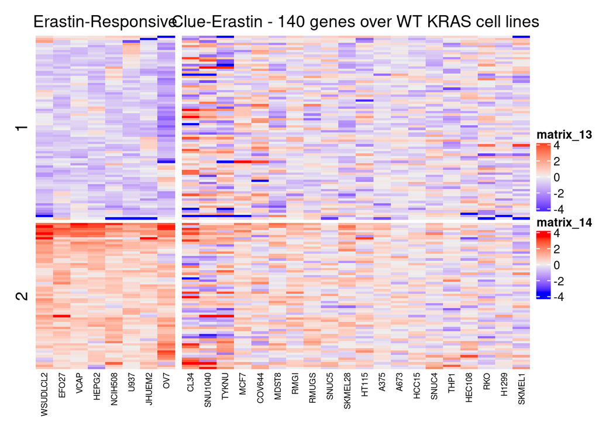

```r
temp %<>% dplyr::filter(KRAS == 'WT')

# filter the clue cell lines for those WT KRAS sstatus
clue.erastin.140 <- clue.erastin %>% dplyr::filter(pr_gene_symbol %in% rownames(lines.erastin)) %>% select(-pr_gene_symbol, -lines)
clue.erastin.140.kras <- clue.erastin.140 %>% dplyr::select(temp$`Cell line`)

set.seed(11)
Heatmap(lines.erastin,
        show_column_dend = F,
        show_row_dend = F,
        show_row_names = F,
        column_names_gp = gpar(fontsize = 7),
        row_km = 2,
        column_title = 'Erastin-Responsive') +

Heatmap(clue.erastin.140.kras,
        show_column_dend = F,
        show_row_dend = F,
        show_row_names = F,
        column_names_gp = gpar(fontsize = 7),
        row_km = 2,
        column_title = 'Clue-Erastin - 140 genes over WT KRAS cell lines')
```